# Zadanie domowe - EDA Danych dotyczących Titanica

- Twoim zadaniem jest wykonanie analizy danych zawartych w załączonym pliku CSV (`26__titanic.csv`).
- Plik znajduje się pod video. Pamiętaj, żeby wrzucić plik do tego samego folderu, w którym znajduje się ten notebook.
- Wykorzystaj nowo nabytą wiedzę z biblioteki `Pandas`
- Jeżeli jest taka konieczność posiłkuj się [code explainerem](https://codeexplainer.imprv.ai/) lub / i [data chatterem](https://datachatter.imprv.ai/) (który również te dane ma dostępne).
- Prześlij na discordzie notebook z rozwiązaniem (`#modul-4-zad2`)
- Pamiętaj:
1. Nie spiesz się
2. Potraktuj zadanie domowe jak prawdziwy projekt
3. Dodawaj opisy, obserwacje, wnioski
4. Dodaj wizualizacje
5. Dodaj konkluzję i wnioski końcowe

Powodzenia!!! I mega zabawy!

## O Danych

Dane o pasażerach Titanica

Zbiór danych zawiera informacje o pasażerach RMS Titanic, który zatonął 15 kwietnia 1912 roku po zderzeniu z górą lodową. Dane obejmują takie atrybuty jak klasa podróży, wiek, płeć, liczba rodzeństwa/małżonków na pokładzie, liczba rodziców/dzieci na pokładzie, cena biletu oraz miejsce zaokrętowania.

Zbiór zawiera także informację o tym, czy pasażer przeżył katastrofę.

Titanic przewoził ponad 2,200 osób, z czego ponad 1,500 zginęło, co czyni tę katastrofę jedną z najbardziej tragicznych w historii morskiej.

Kolumny:

- **pclass** - Klasa biletu
- **survived** - Czy pasażer przeżył katastrofę
- **name** - Imię i nazwisko pasażera
- **sex** - Płeć pasażera
- **age** - Wiek pasażera
- **sibsp** - Liczba rodzeństwa/małżonków na pokładzie
- **parch** - Liczba rodziców/dzieci na pokładzie
- **ticket** - Numer biletu
- **fare** - Cena biletu
- **cabin** - Numer kabiny
- **embarked** - Port, w którym pasażer wszedł na pokład (C = Cherbourg, Q = Queenstown, S = Southampton)
- **boat** - Numer łodzi ratunkowej
- **body** - Numer ciała (jeśli pasażer nie przeżył i ciało zostało odnalezione)
- **home.dest** - Miejsce docelowe

# Analiza danych

Ta analiza ma na celu zbadanie kilku zagadnień związanych z katastrofą statku pasażerskiego Titanic w roku 1912.

- Ocena ryzyka śmierci dla poszczególnych grup pasażerów
- Ocena efekrtywności akcji ratunkowej Do zbadania powyższych zagadnien wykorzystane zostały wyłącznie dane wejściowe jak w opisie powyżej.

# 1. Ogólny przegląd danych

### Przegląd 20 losowych rekordów

|  | pclass | survived | name | sex | age | sibsp | parch | ticket | fare | cabin | embarked | boat | body | home.dest |
| --- | --- | --- | --- | --- | --- | --- | --- | --- | --- | --- | --- | --- | --- | --- |
| 1298 | 3.0 | 0.0 | Wittevrongel, Mr. Camille | male | 36.0 | 0.0 | 0.0 | 345771 | 9.5000 | NaN | S | NaN | NaN | NaN |
| 1002 | 3.0 | 1.0 | McCoy, Miss. Alicia | female | NaN | 2.0 | 0.0 | 367226 | 23.2500 | NaN | Q | 16 | NaN | NaN |
| 1196 | 3.0 | 1.0 | Sheerlinck, Mr. Jan Baptist | male | 29.0 | 0.0 | 0.0 | 345779 | 9.5000 | NaN | S | 11 | NaN | NaN |
| 155 | 1.0 | 1.0 | Hays, Mrs. Charles Melville (Clara Jennings Gr... | female | 52.0 | 1.0 | 1.0 | 12749 | 93.5000 | B69 | S | 3 | NaN | Montreal, PQ |
| 1045 | 3.0 | 0.0 | Myhrman, Mr. Pehr Fabian Oliver Malkolm | male | 18.0 | 0.0 | 0.0 | 347078 | 7.7500 | NaN | S | NaN | NaN | NaN |
| 604 | 3.0 | 1.0 | Abelseth, Miss. Karen Marie | female | 16.0 | 0.0 | 0.0 | 348125 | 7.6500 | NaN | S | 16 | NaN | Norway Los Angeles, CA |
| 626 | 3.0 | 0.0 | Andersson, Miss. Ida Augusta Margareta | female | 38.0 | 4.0 | 2.0 | 347091 | 7.7750 | NaN | S | NaN | NaN | Vadsbro, Sweden Ministee, MI |
| 596 | 2.0 | 1.0 | Wilhelms, Mr. Charles | male | 31.0 | 0.0 | 0.0 | 244270 | 13.0000 | NaN | S | 9 | NaN | London, England |
| 1142 | 3.0 | 0.0 | Rice, Master. Arthur | male | 4.0 | 4.0 | 1.0 | 382652 | 29.1250 | NaN | Q | NaN | NaN | NaN |
| 47 | 1.0 | 1.0 | Calderhead, Mr. Edward Pennington | male | 42.0 | 0.0 | 0.0 | PC 17476 | 26.2875 | E24 | S | 5 | NaN | New York, NY |
| 1112 | 3.0 | 0.0 | Peacock, Miss. Treasteall | female | 3.0 | 1.0 | 1.0 | SOTON/O.Q. 3101315 | 13.7750 | NaN | S | NaN | NaN | NaN |
| 582 | 2.0 | 1.0 | Watt, Miss. Bertha J | female | 12.0 | 0.0 | 0.0 | C.A. 33595 | 15.7500 | NaN | S | 9 | NaN | Aberdeen / Portland, OR |
| 961 | 3.0 | 0.0 | Lennon, Miss. Mary | female | NaN | 1.0 | 0.0 | 370371 | 15.5000 | NaN | Q | NaN | NaN | NaN |
| 540 | 2.0 | 1.0 | Quick, Miss. Phyllis May | female | 2.0 | 1.0 | 1.0 | 26360 | 26.0000 | NaN | S | 11 | NaN | Plymouth, Devon / Detroit, MI |
| 393 | 2.0 | 0.0 | Denbury, Mr. Herbert | male | 25.0 | 0.0 | 0.0 | C.A. 31029 | 31.5000 | NaN | S | NaN | NaN | Guernsey / Elizabeth, NJ |
| 804 | 3.0 | 0.0 | Foley, Mr. William | male | NaN | 0.0 | 0.0 | 365235 | 7.7500 | NaN | Q | NaN | NaN | Ireland |
| 1258 | 3.0 | 1.0 | Touma, Mrs. Darwis (Hanne Youssef Razi) | female | 29.0 | 0.0 | 2.0 | 2650 | 15.2458 | NaN | C | C | NaN | NaN |
| 247 | 1.0 | 1.0 | Rothschild, Mrs. Martin (Elizabeth L. Barrett) | female | 54.0 | 1.0 | 0.0 | PC 17603 | 59.4000 | NaN | C | 6 | NaN | New York, NY |
| 1238 | 3.0 | 1.0 | Tenglin, Mr. Gunnar Isidor | male | 25.0 | 0.0 | 0.0 | 350033 | 7.7958 | NaN | S | 13 15 | NaN | NaN |
| 1246 | 3.0 | 0.0 | Thorneycroft, Mr. Percival | male | NaN | 1.0 | 0.0 | 376564 | 16.1000 | NaN | S | NaN | NaN | NaN |

### Podstawowa informacja o danych

```
<class 'pandas.core.frame.DataFrame'>
RangeIndex: 1310 entries, 0 to 1309
Data columns (total 14 columns):
 #   Column     Non-Null Count  Dtype
---  ------     --------------  -----
 0   pclass     1309 non-null   float64
 1   survived   1309 non-null   float64
 2   name       1309 non-null   object
 3   sex        1309 non-null   object
 4   age        1046 non-null   float64
 5   sibsp      1309 non-null   float64
 6   parch      1309 non-null   float64
 7   ticket     1309 non-null   object
 8   fare       1308 non-null   float64
 9   cabin      295 non-null    object
 10  embarked   1307 non-null   object
 11  boat       486 non-null    object
 12  body       121 non-null    float64
 13  home.dest  745 non-null    object
dtypes: float64(7), object(7)
memory usage: 143.4+ KB
```

### Podsumowanie statystyk parametrów

|  | pclass | survived | age | sibsp | parch | fare | body |
| --- | --- | --- | --- | --- | --- | --- | --- |
| count | 1309.000000 | 1309.000000 | 1046.000000 | 1309.000000 | 1309.000000 | 1308.000000 | 121.000000 |
| mean | 2.294882 | 0.381971 | 29.881135 | 0.498854 | 0.385027 | 33.295479 | 160.809917 |
| std | 0.837836 | 0.486055 | 14.413500 | 1.041658 | 0.865560 | 51.758668 | 97.696922 |
| min | 1.000000 | 0.000000 | 0.166700 | 0.000000 | 0.000000 | 0.000000 | 1.000000 |
| 25% | 2.000000 | 0.000000 | 21.000000 | 0.000000 | 0.000000 | 7.895800 | 72.000000 |
| 50% | 3.000000 | 0.000000 | 28.000000 | 0.000000 | 0.000000 | 14.454200 | 155.000000 |
| 75% | 3.000000 | 1.000000 | 39.000000 | 1.000000 | 0.000000 | 31.275000 | 256.000000 |
| max | 3.000000 | 1.000000 | 80.000000 | 8.000000 | 9.000000 | 512.329200 | 328.000000 |

### Wnioski z ogólnego przeglądu danych * Kolumny w tabeli odpowiadają opisowi danych * 7 kolumn zawiera wartości liczbowe

# 2. Analiza brakujących wartości

### Sprawdzenie pustych rekordów

|  | pclass | survived | name | sex | age | sibsp | parch | ticket | fare | cabin | embarked | boat | body | home.dest |
| --- | --- | --- | --- | --- | --- | --- | --- | --- | --- | --- | --- | --- | --- | --- |
| 1309 | NaN | NaN | NaN | NaN | NaN | NaN | NaN | NaN | NaN | NaN | NaN | NaN | NaN | NaN |

|  | Liczba brakujących wartości |
| --- | --- |
| pclass | 1 |
| survived | 1 |
| name | 1 |
| sex | 1 |
| age | 264 |
| sibsp | 1 |
| parch | 1 |
| ticket | 1 |
| fare | 2 |
| cabin | 1015 |
| embarked | 3 |
| boat | 824 |
| body | 1189 |
| home.dest | 565 |

Uwaga: plik CVS jest kompletny, ale po wczytaniu widoczna jest dodatkowy wierz na końcu rekordu. Wymaga akcji naprawczej w następnym kroku

Usuwanie rekordów zawierających wszystkie pola puste...

|  | pclass | survived | name | sex | age | sibsp | parch | ticket | fare | cabin | embarked | boat | body | home.dest |
| --- | --- | --- | --- | --- | --- | --- | --- | --- | --- | --- | --- | --- | --- | --- |

### Puste rekordy usunięto!

|  | Liczba brakujących wartości |
| --- | --- |
| pclass | 0 |
| survived | 0 |
| name | 0 |
| sex | 0 |
| age | 263 |
| sibsp | 0 |
| parch | 0 |
| ticket | 0 |
| fare | 1 |
| cabin | 1014 |
| embarked | 2 |
| boat | 823 |
| body | 1188 |
| home.dest | 564 |

|  | pclass | survived | name | sex | age | sibsp | parch | ticket | fare | cabin | embarked | boat | body | home.dest |
| --- | --- | --- | --- | --- | --- | --- | --- | --- | --- | --- | --- | --- | --- | --- |

### Sprawdzenie duplikatów rekordów

```
Nie znaleziono duplikatów rekordów
```

### Sprawdzenie repezentatywności

[output not shown]

1307 rows × 2 columns

|  | Unikalna wartość dla płci | Liczba wystąpień |
| --- | --- | --- |
| 0 | (male,) | 843 |
| 1 | (female,) | 466 |

|  | Unikalna wartość dla wieku | Liczba wystąpień |
| --- | --- | --- |
| 0 | (24.0,) | 47 |
| 1 | (22.0,) | 43 |
| 2 | (21.0,) | 41 |
| 3 | (30.0,) | 40 |
| 4 | (18.0,) | 39 |
| ... | ... | ... |
| 93 | (20.5,) | 1 |
| 94 | (11.5,) | 1 |
| 95 | (0.6667,) | 1 |
| 96 | (0.4167,) | 1 |
| 97 | (80.0,) | 1 |

98 rows × 2 columns

|  | Unikalna wartość dla przetrwania | Liczba wystąpień |
| --- | --- | --- |
| 0 | (0.0,) | 809 |
| 1 | (1.0,) | 500 |

|  | Unikalna wartość dla klasy biletu | Liczba wystąpień |
| --- | --- | --- |
| 0 | (3.0,) | 709 |
| 1 | (1.0,) | 323 |
| 2 | (2.0,) | 277 |

|  | Unikalna wartość dla portu zapokładowania | Liczba wystąpień |
| --- | --- | --- |
| 0 | (S,) | 914 |
| 1 | (C,) | 270 |
| 2 | (Q,) | 123 |

|  | Unikalna wartość dla kabiny | Liczba wystąpień |
| --- | --- | --- |
| 0 | (C23 C25 C27,) | 6 |
| 1 | (G6,) | 5 |
| 2 | (B57 B59 B63 B66,) | 5 |
| 3 | (B96 B98,) | 4 |
| 4 | (F4,) | 4 |
| ... | ... | ... |
| 181 | (B82 B84,) | 1 |
| 182 | (B80,) | 1 |
| 183 | (B79,) | 1 |
| 184 | (B73,) | 1 |
| 185 | (T,) | 1 |

186 rows × 2 columns

|  | Unikalna wartość dla celu podróży | Liczba wystąpień |
| --- | --- | --- |
| 0 | (New York, NY,) | 64 |
| 1 | (London,) | 14 |
| 2 | (Montreal, PQ,) | 10 |
| 3 | (Paris, France,) | 9 |
| 4 | (Cornwall / Akron, OH,) | 9 |
| ... | ... | ... |
| 364 | (Hessle, Yorks,) | 1 |
| 365 | (Holley, NY,) | 1 |
| 366 | (Hornsey, England,) | 1 |
| 367 | (Illinois, USA,) | 1 |
| 368 | (Kontiolahti, Finland / Detroit, MI,) | 1 |

369 rows × 2 columns

### Sprawdzenie, gdzie w DataFrame zawarte sa liczby, stringi tekstowe lub wartości niezdefiniowane

|  | Numeric | String | Undefined |
| --- | --- | --- | --- |
| pclass | True | False | False |
| survived | True | False | False |
| name | False | True | False |
| sex | False | True | False |
| age | True | False | True |
| sibsp | True | False | False |
| parch | True | False | False |
| ticket | False | True | False |
| fare | True | False | True |
| cabin | False | True | True |
| embarked | False | True | True |
| boat | False | True | True |
| body | True | False | True |
| home.dest | False | True | True |

# 3. Analiza pojedynczych zmiennych

## Statystyka wieku uczestników rejsu z podziałem na płeć

### Liczba podróżujących w przekroju wiekowym

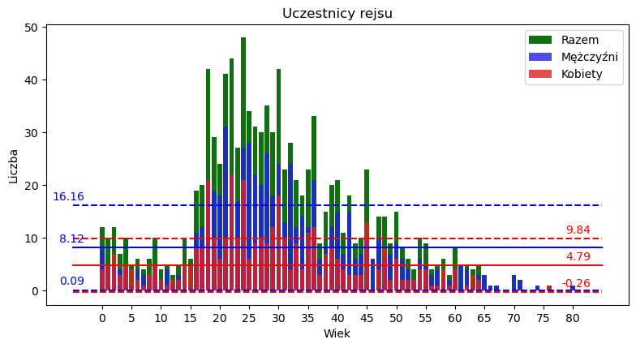

```
średnia dla male 8.12
odchylenie standardowe dla male 8.04
średnia dla female 4.79
odchylenie standardowe dla female 5.05
```

```
Całkowita liczba podróżujących 1309
sex
male      843
female    466
Name: count, dtype: int64
```

|  | Statystyka | Wartość |
| --- | --- | --- |
| 0 | Średnia | 29.881135 |
| 1 | Odchylenie standardowe | 14.413500 |
| 2 | Mediana | 28.000000 |
| 3 | Kwartyl 1 | 21.000000 |
| 4 | Kwartyl 3 | 39.000000 |

## Statystyka ofiar i ocalonych

### Ocaleni w grupach wiekowych

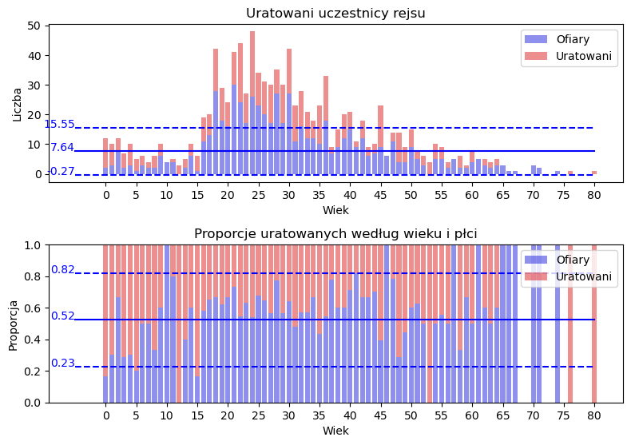

```
średnia dla ofiar 0.52
odchylenie standardowe dla ofiar 0.30
średnia dla female 0.38
odchylenie standardowe dla female 0.27
```

Liczby ofiar i ocalałych

[output not shown]

Staystyki wieku ocalałych

| sex | Średnia | Odchylenie standardowe | Mediana | Kwartyl 1 | Kwartyl 3 |
| --- | --- | --- | --- | --- | --- |
| female | 29.815354 | 14.769278 | 28.5 | 20.0 | 39.0 |
| male | 26.977778 | 15.553884 | 27.0 | 19.5 | 36.0 |

Staystyki wieku ofiar

| sex | Średnia | Odchylenie standardowe | Mediana | Kwartyl 1 | Kwartyl 3 |
| --- | --- | --- | --- | --- | --- |
| female | 25.255208 | 13.476880 | 24.5 | 18.0 | 31.25 |
| male | 31.516412 | 13.796345 | 29.0 | 22.0 | 40.00 |

Spektrum podróżujących w różnych klasach biletów

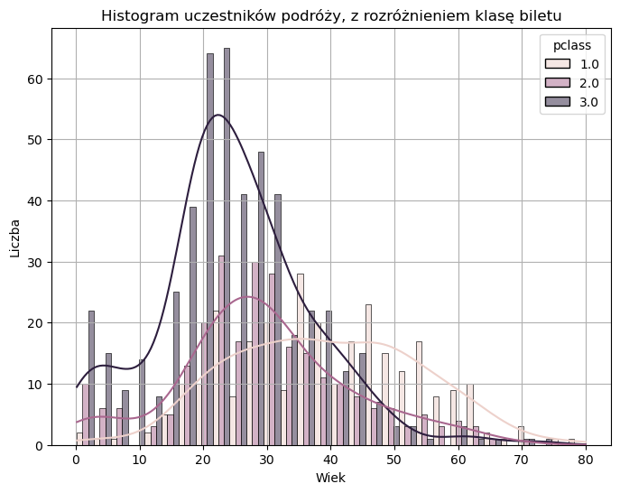

### Statystyki dla klas biletów

```
liczebność klasy 1.0: 323
liczebność klasy 2.0: 277
liczebność klasy 3.0: 709
```

### Staystyka cen biletów

```
          średnia  odchylenie standardowe  mediana  kwartyl 1  kwartyl 3
pclass
1.0     87.508992               80.447178  60.0000    30.6958   107.6625
2.0     21.179196               13.607122  15.0458    13.0000    26.0000
3.0     13.302889               11.494358   8.0500     7.7500    15.2458
```

# 4. Transformacja danych

### Dodanie serii obliczonych na podstawie danych

### Lista nazwisk

|  | Unikalna wartość dla nazwiska | Liczba wystąpień |
| --- | --- | --- |
| 0 | (Andersson,) | 11 |
| 1 | (Sage,) | 11 |
| 2 | (Goodwin,) | 8 |
| 3 | (Asplund,) | 8 |
| 4 | (Davies,) | 7 |
| ... | ... | ... |
| 870 | (Humblen,) | 1 |
| 871 | (Hunt,) | 1 |
| 872 | (Hyman,) | 1 |
| 873 | (Ibrahim Shawah,) | 1 |
| 874 | (van Melkebeke,) | 1 |

875 rows × 2 columns

### Lista imion

|  | Unikalna wartość dla nazwiska | Liczba wystąpień |
| --- | --- | --- |
| 0 | (Mr. John,) | 13 |
| 1 | (Mr. William,) | 10 |
| 2 | (Mr. Patrick,) | 10 |
| 3 | (Mr. James,) | 9 |
| 4 | (Mr. Joseph,) | 7 |
| ... | ... | ... |
| 1137 | (Mr. Charles Duane,) | 1 |
| 1138 | (Mr. Charles Edward,) | 1 |
| 1139 | (Mr. Charles Emil Henry,) | 1 |
| 1140 | (Mr. Charles Eugene,) | 1 |
| 1141 | (the Countess. of (Lucy Noel Martha Dyer-Edwar... | 1 |

1142 rows × 2 columns

## Wnioski z transformacji danych

- Niektóre serie zawierały dane tekstowe, nie dające się do obliczeń: sex, embarked - zostały uzupełnione nowymi kolumnnami zawierającymi wartości liczbowe 0 lub 1
- Niektóre fragmenty informacji były były częścia dłuższych łańcuchów: imię, nazwisko, deck - zostały wydzielone z istniejących kolumn
- W celu głębszej analizy zostały stworzone nowe grupy zależnie od wieku i płci: dzieci, kobiety, seniorzy, mężczyźni

# 5. Analiza zależności między zmiennymi

### Macierz korelacji

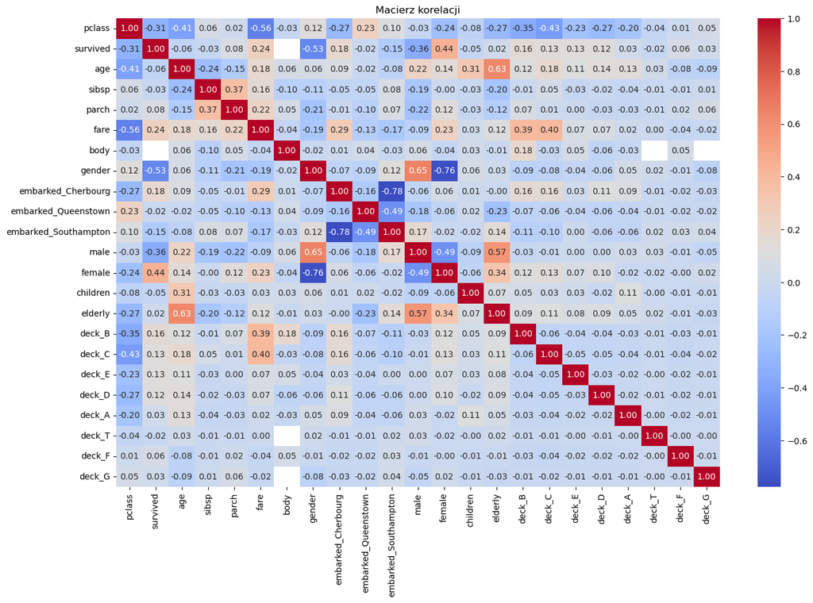

### Uwagi

- zaobserwowana korelacja kilku danch sugeruje konieczność zbadania ryzyka śmierci w zależności od płci, klasy biletu, pokładu oraz portu embarkowania

### Ceny biletów w różnych grupach wiekowych

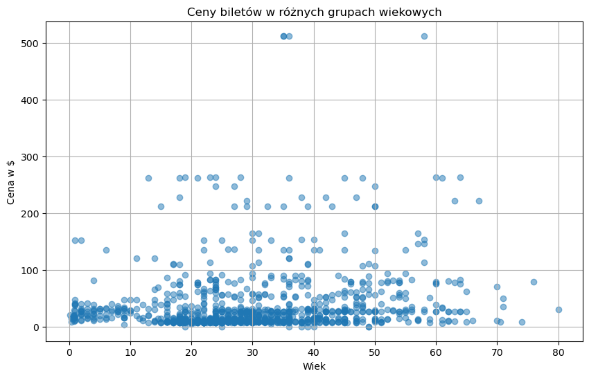

Uwagi dotyczące rozkładu cen biletów w kategoiacg wiekowych

- Powyższa wizualizacja danych pokazuje, że większość pasażerów posiadała bilety w cenie poniże 100$, natomiast stosunkowo nieliczni pasażerowie koszystali z oferty wielokrotni przewuższajacej cenowo pozostałe
- Interesujące może być skorelowanie tych różnic ze statystykami uratowanych i ofiar śmiertelnych

### Rozkład liczby pasażerów na łodziach ratunkowych

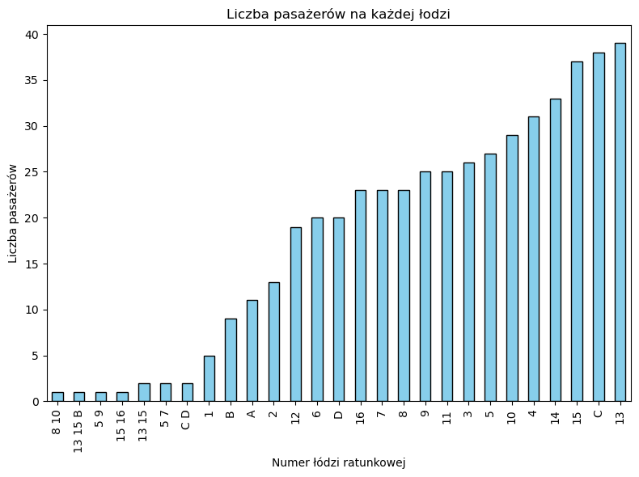

### Uwagi dotyczące rozkładu pasażerów na łodzie ratunkowe

- Rozkład liczby pasaęrów na łodziach ratunkowych pokazuje duże róznice dla różnych łodzi
- Dane na temat łodzi są prawdopodobnie niepełne, ponieważ tulko łodzie z rozbitkami zostały uwzględnione w statystykach

### Rozkład klasy biletu na łodzie

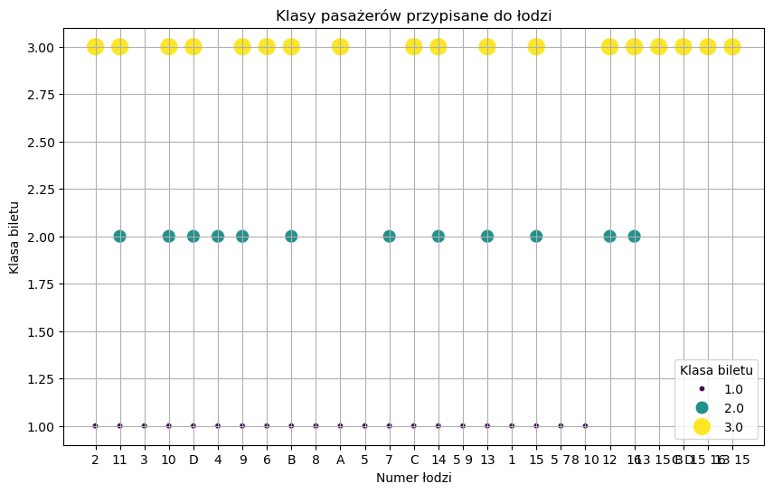

### Rozkład klas biletów według pokładów

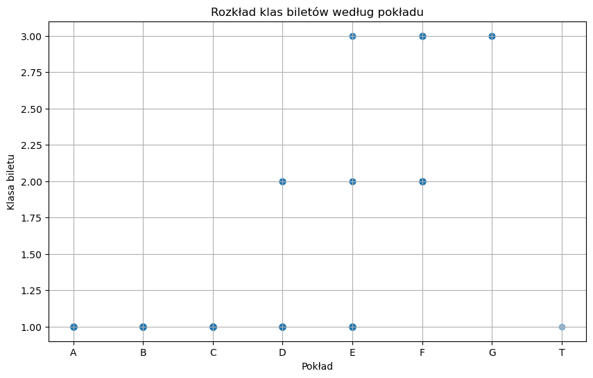

### Uwagi dotyczące rozkładu klas biletów w odniesieniu do pokładów

- Grupa statystyk zawiera 295 rekordów z przyporządkowaniem numeru cabiny, pozostałe nie były brane pod uwagę w tej części analizy
- Powyższy plot danych jednoznacznie wskazuje na segregację pasażerów i rozdzielenie fizyczne przez umieszczenie na różnych pokładach

### Rozkład cen biletów w zależności od pokładu

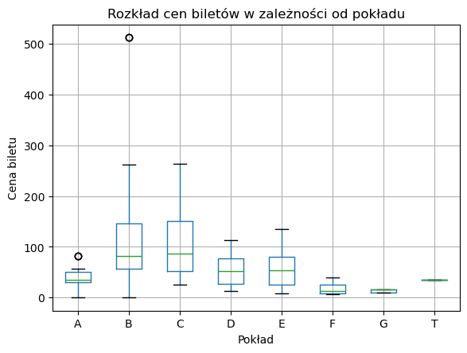

### Uwagi dotyczące rozkładu cen biletów w zależności od pokładu

- Grupa statystyk zawiera 295 rekordów z przyporządkowaniem numeru cabiny, pozostałe nie były brane pod uwagę w tej części analizy
- powyższy wykazyje, że pokłady bardziej prominentne w sensie ceny biletu były mocniej odseparowane od pozostałych co może isię przekładać na fakt, że miały lepszy dostę do łodzi ratunkowych

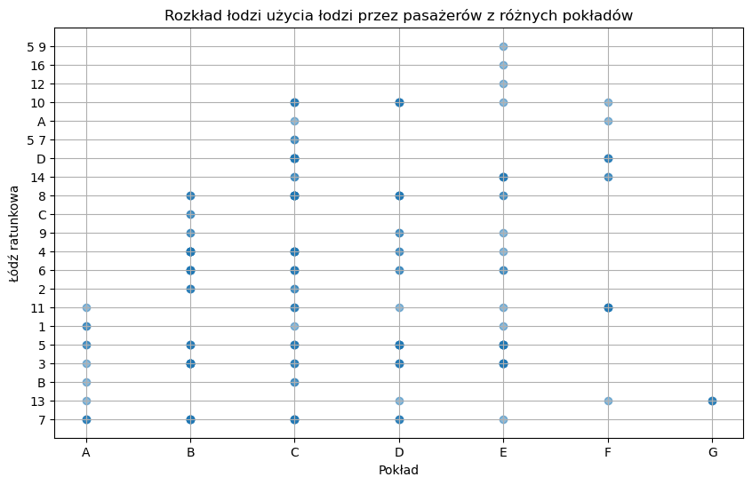

### Uwagi dotyczące przypisania łodzi ratunkowych do decków

- Grupa statystyk zawiera 295 rekordów z przyporządkowaniem numeru cabiny, pozostałe nie były brane pod uwagę w tej części analizy
- Przypisanie łodzi ratunkowych do pokładów njest wynikiem analizy danych, gdzie relacją między pasażerami, a lodiami i poładami jest dostępna
- Spostrzerzenia na temat rozkładu pozwalają stwierdzić pewien stopień separacji, co może wynikć z fizycznej dostępności lub jej braku oraz z uwarunkowań czasowych spowodowanych stopniowym zatapianiem kolejnych pokładów, a neastępnie przełamaniem kadłuba statku

### Statystyki przetwania dla pokładów

| deck | female_survived | male_survived | female_total | male_total | female_deaths | male_deaths |
| --- | --- | --- | --- | --- | --- | --- |
| A | 3.0 | 8.0 | 4 | 18 | 1.0 | 10.0 |
| B | 36.0 | 11.0 | 36 | 29 | 0.0 | 18.0 |
| C | 42.0 | 15.0 | 46 | 48 | 4.0 | 33.0 |
| D | 23.0 | 9.0 | 23 | 23 | 0.0 | 14.0 |
| E | 18.0 | 12.0 | 19 | 22 | 1.0 | 10.0 |
| F | 8.0 | 5.0 | 8 | 13 | 0.0 | 8.0 |
| G | 3.0 | 0.0 | 5 | 0 | 2.0 | 0.0 |
| T | 0.0 | 0.0 | 0 | 1 | 0.0 | 1.0 |

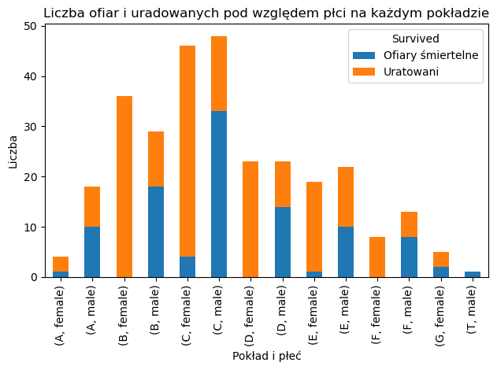

### Oszacowanie ryzyka śmierci według wieku i płci

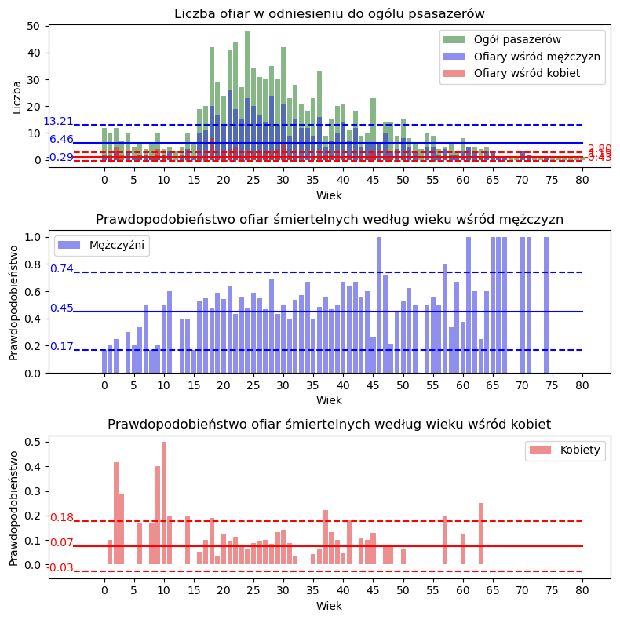

```
Liczba ofiar smiertelnych dla kobiet i mężczyzn  na 1046 pasażerów
 sex
female     96
male      523
dtype: int64
50.00% mężczyzn poniosło śmierć
9.18% kobiet poniosło śmierć
średnia prawdopodobieństwo dla mężczyzn 0.45
Odchylenie standardowe  prawdopodobiieństwa dla mężczyzn 0.29
średnia Prawdopodobieństwa dla kobiet 0.07
Odchylenie standardowe prawdopodobiieństwa dla kobiet 0.10
```

### Wnioski wynikające z analizy wieku i płci ofiar śmiertelnych

- Wyniki analizy zalęności śmiertelności pod wzgłedem płci wykazują około pięciokronie wyższą sumarycznie liczbę ofir wśród mężczyzn niż wśród kobiet, odpowiednio 50% i 9.18% w stosunku do całej populacji
- Rozkład liczb przypadków śmiertelnych w przypadlku mężczyzn w stodunku do całkowitej liczby pasażerów wskazuje stosunkowo niską zależność od wieku, natomiast wśród kobiet można zaobserwować większe zróżnicowanie w zależności od wieku

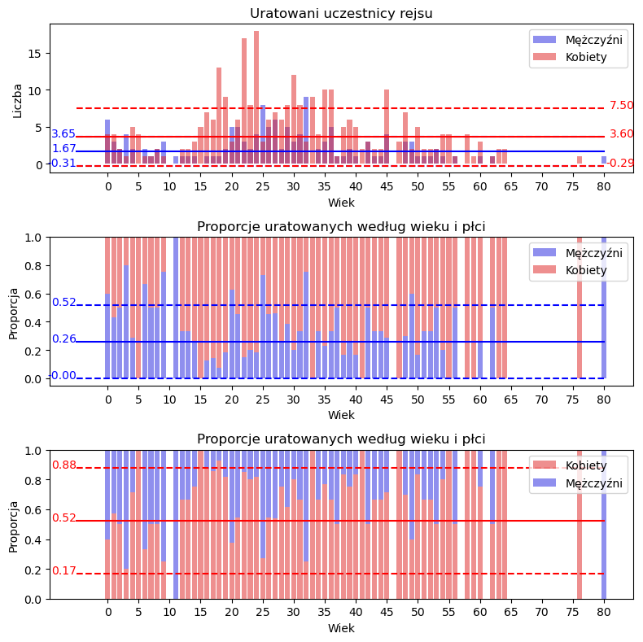

```
Liczba uratowanych  kobiet i mężczyzn  427
31.62% uratowanych stanowią mężczyźni
68.38% uratowanych stanowią kobiety
Średnia proporcji dla mężczyzn 0.26
Odchylenie standardowe  proporcji dla mężczyzn 0.26
średnia proporcji dla dla kobiet 0.52
Odchylenie standardowe proporcji dla dla kobiet 0.36
```

## Wioski z analizy proprcji liczb utartowanych

- Analiza porównwcza liczb uratowanych kobiet i mężczyzn wskazuje na proporcje 2:1 na korzyść kobiet. To może również wskazywać na procedurę ratunkową i zasady umieszczania osób w szalupach ratunkowych
- Nie zaobserwowano wyraźnych zależności związanch z wiekiem uratowanych

### Ofiary śmiertelne według wieku i płci

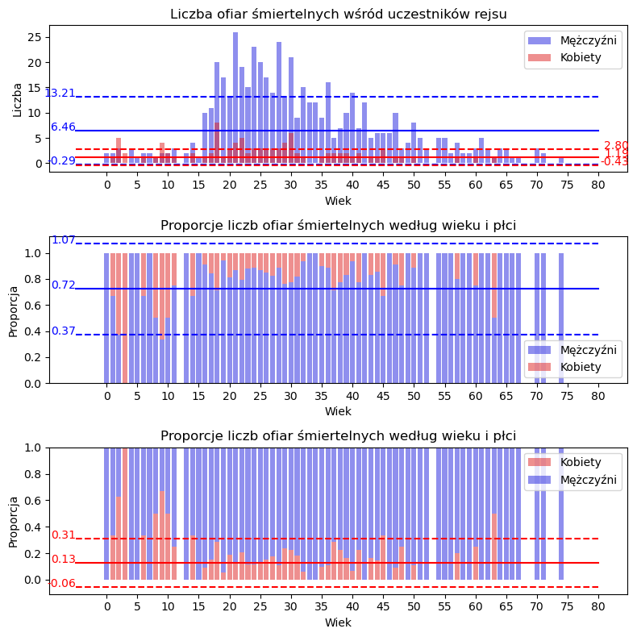

```
Liczba zmarłych kobiet i mężczyzn  619
84.49% ofiar śmiertelnych stanowią mężczyźni
15.51% ofiar śmiertelnych stanowią kobiety
średnia proporcji dla dla kobiet 0.13
Odchylenie standardowe proporcji dla dla kobiet 0.18
Średnia proporcji dla mężczyzn 0.72
Odchylenie standardowe  proporcji dla mężczyzn 0.35
Proporcje ofiar śmiertelnych w każdej grupie płci osobno:
Odsetek ofiar śmiertelnych w grupie kobiet 24.74%
Odsetek ofiar śmiertelnych w grupie mężczyzn 79.48%
```

### Wnoski z a analizy liczb ofiar śmiertelnych pod względem wieku i płci

- Analiza liczby ofiar śmiertelnych oraz proporcji zależnych od płci nasuwa przypuszczenie,że dostęp do szalup ratunkowych byl dalece niewystarczający, a reguła o tym kto otrzyma miejsce w szalupie jest dyktowana z góry założanym przydziałem proporcjonalnym do miejsc w szalupie, a nie proporcjami zapotrzebowania wszytkich pasażerów. Dlategśmiertelność wśró pasażerów płci męskiej jest wielokroenie wyższa niż wśród kobiet
- Wyraźnaźna jest dysroporcja ryzyka śmierci dla płci żeńskiej i męskiej wynoszące odpowiednio 24.74% i 79.48%

### Liczba ofiar śmiertelnych dla różnych klas biletu

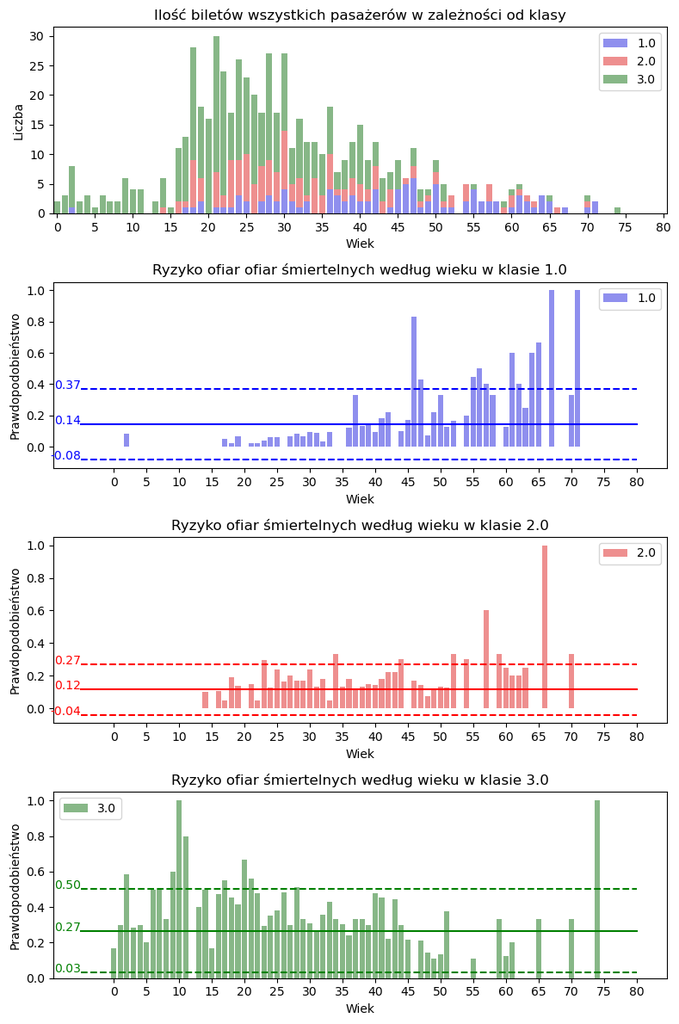

```
Liczba zmarłych we wszystkich klasach biletów  619
16.64% ofiar śmiertelnych stanowią pasażerowie w klasie 1.0
23.59% ofiar śmiertelnych stanowią pasażerowie w klasie 2.0
59.77% ofiar śmiertelnych stanowią pasażerowie w klasie 3.0
Średnia proporcji dla pclass 1.0 0.14
Odchylenie standardowe  pclass 1.0 dla mężczyzn 0.23
średnia proporcji dla pclass 2.0 0.12
Odchylenie standardowe pclass 2.0 dla dla kobiet 0.16
średnia proporcji dla pclass 3.0 0.27
Odchylenie standardowe pclass 3.0 dla dla kobiet 0.23
```

### Liczba uratowancyh dla różnych klas biletu

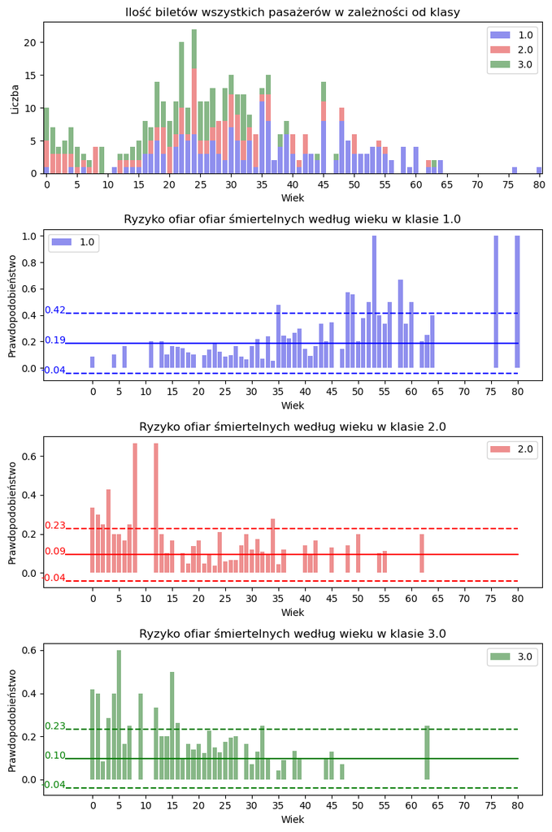

```
Liczba zmarłych we wszystkich klasach biletów  427
42.39% ofiar uratowancych stanowią pasażerowie w klasie 1.0
26.93% ofiar uratowancych stanowią pasażerowie w klasie 2.0
30.68% ofiar uratowancych stanowią pasażerowie w klasie 3.0
Średnia proporcji dla pclass 1.0 0.19
Odchylenie standardowe  pclass 1.0 dla mężczyzn 0.23
średnia proporcji dla pclass 2.0 0.09
Odchylenie standardowe pclass 2.0 dla dla kobiet 0.13
średnia proporcji dla pclass 3.0 0.10
Odchylenie standardowe pclass 3.0 dla dla kobiet 0.14
```

### Wnioski z analizy zależności między klasą biletu a ryzykiem szansą na zachowanie życia w katastrofie Titanica

- Najliczniejszą grupą uratowanych w odniesieniu do klasy biletu jest 1.0, która stanowi w przybliżeniu 42% wszystkich uratowanych
- Ze względu na nipełna listę kabin nie jest możliwa pełna ocen zależności śiertelności od pokładu, ale ocena na podstawie klasy biletu pozwala na dokonanie przybliżonej oceny

# 6. Analiza danych odstających

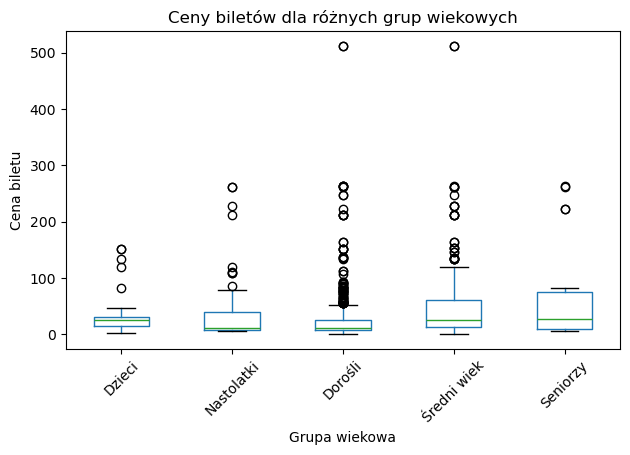

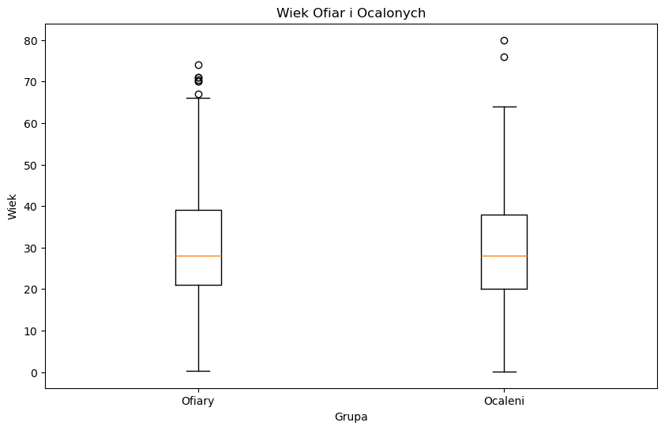